# challenge_torch

1. **Introduction**
   - Overview of the Problem
   - Objective
2. **Results Summary**
   - Overall Model Performance Comparison
   - On-Peak vs Off-Peak Comparison
   - Important Notes for Model Usage
3. **Exploratory Data Analysis (EDA)**
   - Data Overview
   - Feature Relationships
     - Temperature vs Real-Time Price
     - Day-Ahead Price vs Real-Time Price
   - Time-Based Trends
     - Hourly
     - Weekly
     - Seasonal
   - Outlier Detection
4. **Machine Learning Models**
   - Overview of Models Used
   - Preprocessing Steps
     - Data Preparation
     - Feature Engineering
     - Outlier Removal
     - Normalization and Sequencing
   - Model Architectures and Training
     - LSTM Training
     - Transformer Training
   - Model Performance Visualization
5. **Model Comparison and Discussion**
   - Direct Comparison: LSTM vs. Transformer
   - RMSE and MAPE Analysis
   - On-Peak vs Off-Peak Comparison (LSTM)
6. **Conclusion**
   - Overall Model Comparison
   - Preferred Model Choice
   - Practical Implications of Model Deployment
7. **Further Ideas**
   - Ensemble Models
   - Feature Engineering
   - Outlier Identification Improvements
   - ARIMA and Hybrid Model Approach
   - Model Architecture Variations
   - Hyperparameter Tuning
8. **Real-World Deployment Considerations**
   - Data Distribution Monitoring
   - Retraining Models
   - Handling Rare Events with Additional Features

# Energy Prices Prediction Challenge

This notebook analyzes energy price prediction using machine learning models on a dataset containing real-time prices, day-ahead prices, temperature, and time features. Time-series forecasting is a classical autoregressive problem due to its dependency on past data. Therefore, sequential algorithms like LSTM and Transformers are used.

The results of both LSTM and Transformer are comparable. Both models have around same number of parameters but transformer takes double the epochs to achieve same results. Thus, LSTM is preferred in our case.

In the end, results are visualized for both models and RMSE is discussed. Additionally, practical implications of this model in deployment are also discussed along with the suggestions.

#### Results

The models were trained for the given times and the following results were obtained.

| Model | Training Epochs | Estimated Training Time | Test set RMSE | Test set MAPE (%) |
| --- | --- | --- | --- | --- |
| LSTM | 50 | ~8 mins | 4.1015 | 1932026739.73 |
| Transformer | 100 | ~20 mins | 3.9331 | 2034685364.99 |

**On-Peak vs Off-Peak Comparison**

LSTM was used for on-peak and off-peak comparison.

On Peak RMSE : 4.5324, Off Peak RMSE : 4.3205

**Note:** When Train = True is set, the models start training and replace the trained best models. If the above results are not obtained or complete training cannot be performed, please copy the models from `saved_models_backup` folder to `saved_models`(default location for saving models) to load the trained best models.

### Importing Libraries

Install the required libraries using

`pip install -r requirements.txt`

```python
# General libraries for data manipulation and numerical operations
import numpy as np
import pandas as pd

# Visualization libraries
import matplotlib.pyplot as plt
import seaborn as sns
import matplotlib.image as mpimg

# Statistical and modeling libraries
import sklearn
from sklearn.metrics import r2_score
from sklearn.model_selection import train_test_split
from sklearn.preprocessing import StandardScaler, MinMaxScaler
from scipy.stats import linregress

# Deep learning libraries
import torch
import torch.nn as nn
from torch.utils.data import DataLoader, TensorDataset
import torchinfo

from models import LSTMModel
from utils import classify_hour, train_model, evaluate_model, evaluate_model_with_dataloader
```

```python
# Setting Configuration Variables
fig_size = (16, 4)
TRAIN = False
```

### Data Loading

```python
pricing_data_df = pd.read_csv("data/price_temp_data.csv")
pricing_data_df = pricing_data_df.rename(columns={"Unnamed: 0" : "datetime",
                                                  "rt_energy" : "rt_price",
                                                  "dah_energy" : "dah_price",
                                                  "temp_BAR" : "temp"})
pricing_data_df['datetime'] = pd.to_datetime(pricing_data_df['datetime'])
pricing_data_df['year'] = pricing_data_df['datetime'].dt.year # to normalize the scale of years i.e. 1, 2, 3...
pricing_data_df['hour'] = pricing_data_df['datetime'].dt.hour + pricing_data_df['datetime'].dt.minute/60
pricing_data_df['day_of_year'] = pricing_data_df['datetime'].dt.dayofyear
pricing_data_df['time_of_year'] = pricing_data_df['day_of_year'] + pricing_data_df['hour']/24
pricing_data_df['day_of_week'] = pricing_data_df['datetime'].dt.dayofweek
pricing_data_df['week_of_year'] = pricing_data_df['datetime'].dt.isocalendar().week
pricing_data_df['peak_type'] = pricing_data_df['hour'].apply(classify_hour)

pricing_data_df.head()
```

|  | datetime | rt_price | dah_price | temp | month | hour | season | year | day_of_year | time_of_year | day_of_week | week_of_year | peak_type |
| --- | --- | --- | --- | --- | --- | --- | --- | --- | --- | --- | --- | --- | --- |
| 0 | 2019-04-01 00:00:00 | 29.62 | 54.84 | 21.9 | 4 | 0.00 | 2 | 2019 | 91 | 91.000000 | 0 | 14 | off_peak |
| 1 | 2019-04-01 00:15:00 | 28.45 | 54.84 | 21.8 | 4 | 0.25 | 2 | 2019 | 91 | 91.010417 | 0 | 14 | off_peak |
| 2 | 2019-04-01 00:30:00 | 27.85 | 54.84 | 21.7 | 4 | 0.50 | 2 | 2019 | 91 | 91.020833 | 0 | 14 | off_peak |
| 3 | 2019-04-01 00:45:00 | 22.75 | 54.84 | 21.6 | 4 | 0.75 | 2 | 2019 | 91 | 91.031250 | 0 | 14 | off_peak |
| 4 | 2019-04-01 01:00:00 | 22.84 | 54.18 | 21.5 | 4 | 1.00 | 2 | 2019 | 91 | 91.041667 | 0 | 14 | off_peak |

## Exploratory Data Analysis

### Exploring Feature Relationship with Data

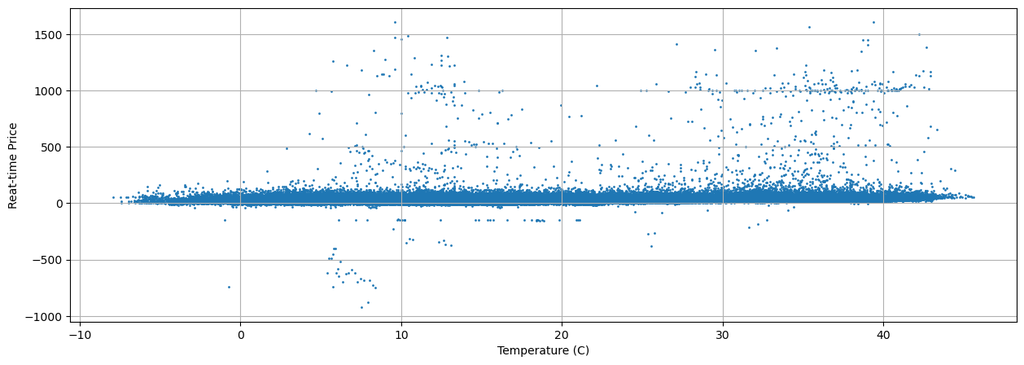

```python
# Checking relationship between Tempearature and Real-Time Price
plt.figure(figsize=(15, 5))
plt.scatter(pricing_data_df['temp'], pricing_data_df['rt_price'], s=1)
plt.xlabel("Temperature (C)")
plt.ylabel("Reat-time Price")
plt.grid(True)
plt.show()
```

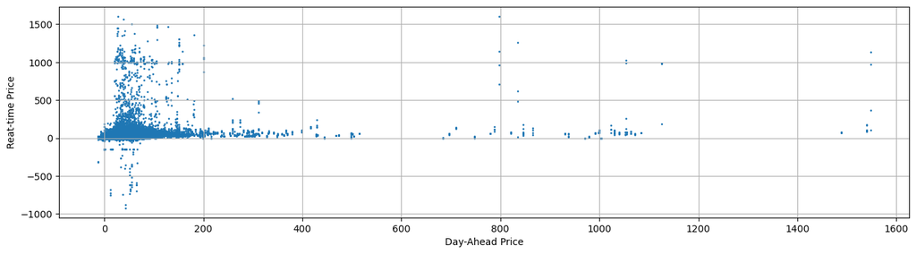

```python
# Checking relationship between Day-Ahead Price and Real-Time Price
plt.figure(figsize=fig_size)
plt.scatter(pricing_data_df['dah_price'], pricing_data_df['rt_price'], s=1)
plt.xlabel("Day-Ahead Price")
plt.ylabel("Reat-time Price")
plt.grid(True)
plt.show()
```

```python
slope, intercept, r_value, p_value, std_err = linregress(pricing_data_df['dah_price'], pricing_data_df['rt_price'])
r_squared = r_value**2

print("R-squared with Day-Ahead Price: {:.3f}".format(r_squared))

slope, intercept, r_value, p_value, std_err = linregress(pricing_data_df['temp'], pricing_data_df['rt_price'])
r_squared = r_value**2

print("R-squared with Temperature: {:.3f}".format(r_squared))
```

```
R-squared with Day-Ahead Price: 0.023
R-squared with Temperature: 0.010
```

#### Effect of Temperature and Day-Ahead Prices on Real-time Prices

**Day-Ahead Prices:** Day-ahead prices are somewhat related to real-time prices, but the relationship is weaker than expected. Ideally, there should be a strong linear relationship, indicating accurate price prediction and bidding. However, the low r-squared value of 0.023 suggests little linear correlation.

**Temperature:** As expected, temperature has a positive effect on real-time prices. Higher temperatures lead to increased electricity usage for cooling, driving up real-time prices. However, the r-squared value of 0.01 indicates little linear relationship between temperature and real-time prices.

## Exploring Trends in Data

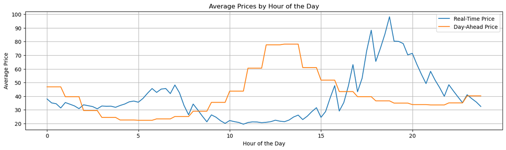

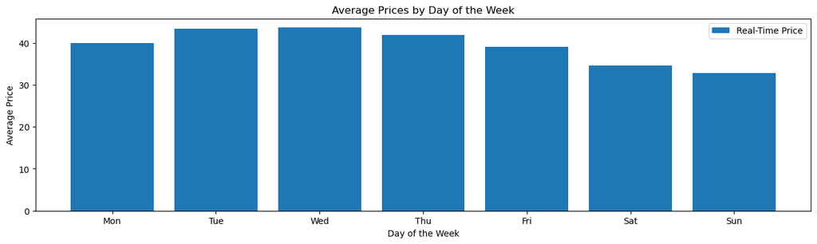

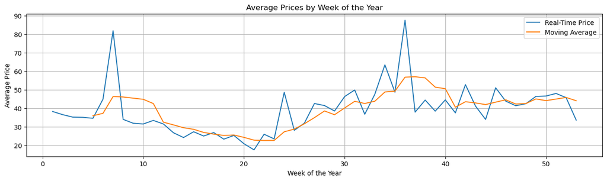

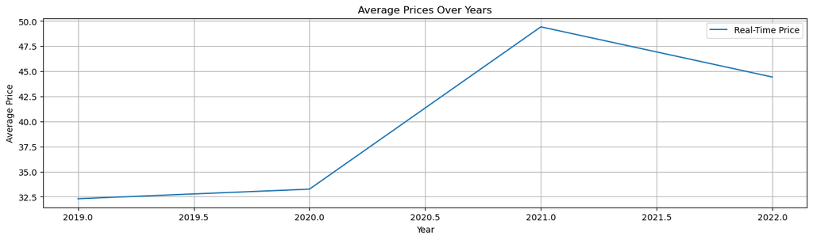

```python
# Trends by Hours of the Day
hourly_avg = pricing_data_df.groupby('hour')[['rt_price', 'dah_price']].mean()
plt.figure(figsize=(fig_size))
plt.plot(hourly_avg.index, hourly_avg['rt_price'], label='Real-Time Price')
plt.plot(hourly_avg.index, hourly_avg['dah_price'], label='Day-Ahead Price')
plt.title('Average Prices by Hour of the Day')
plt.xlabel('Hour of the Day')
plt.ylabel('Average Price')
plt.legend()
plt.grid(True)
plt.show()

# 2. Trends by Days of the Week
weekly_avg = pricing_data_df.groupby('day_of_week')[['rt_price', 'dah_price']].mean()
plt.figure(figsize=fig_size)
plt.bar(weekly_avg.index, weekly_avg['rt_price'], alpha=1, label='Real-Time Price')
plt.title('Average Prices by Day of the Week')
plt.xlabel('Day of the Week')
plt.ylabel('Average Price')
plt.xticks(range(7), ['Mon', 'Tue', 'Wed', 'Thu', 'Fri', 'Sat', 'Sun'])
plt.legend()
plt.show()

# 3. Trends by Weeks of the Year
weekly_yearly_avg = pricing_data_df.groupby('week_of_year')[['rt_price', 'dah_price']].mean()
weekly_yearly_avg['rt_price_moving_avg'] = weekly_yearly_avg['rt_price'].rolling(window=5).mean()

plt.figure(figsize=fig_size)
plt.plot(weekly_yearly_avg.index, weekly_yearly_avg['rt_price'], label='Real-Time Price')
plt.plot(weekly_yearly_avg.index, weekly_yearly_avg['rt_price_moving_avg'], label='Moving Average')
plt.title('Average Prices by Week of the Year')
plt.xlabel('Week of the Year')
plt.ylabel('Average Price')
plt.legend()
plt.grid(True)
plt.show()

# 4. Trends Over Years
yearly_avg = pricing_data_df.groupby('year')[['rt_price', 'dah_price']].mean()
plt.figure(figsize=fig_size)
plt.plot(yearly_avg.index, yearly_avg['rt_price'], label='Real-Time Price')
plt.title('Average Prices Over Years')
plt.xlabel('Year')
plt.ylabel('Average Price')
plt.legend()
plt.grid(True)
plt.show()
```

## Outlier Detection

The scatter plots of temperature and day-ahead prices suggest presence of outliers. Here we attempt to visualize the outliers and make some decision about them.

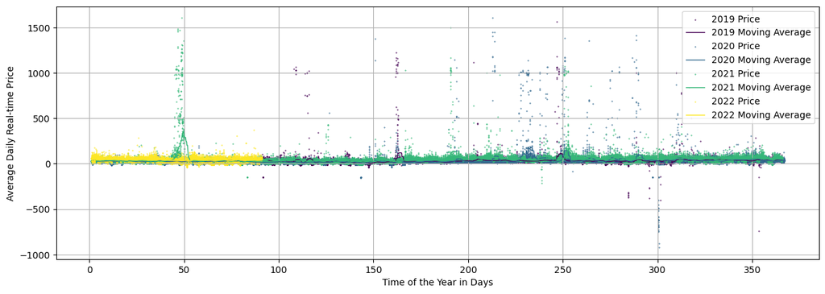

```python
years = pricing_data_df['year'].unique()
colors = plt.cm.viridis(np.linspace(0, 1, len(years)))

plt.figure(figsize=(15, 5))
for year, color in zip(years, colors):
    subset = pricing_data_df[pricing_data_df['year'] == year]
    plt.scatter(subset['time_of_year'], subset['rt_price'], label=f'{year} Price', color=color, alpha=1, s=.2)
    moving_average = subset['rt_price'].rolling(window=300).mean()
    plt.plot(subset['time_of_year'], moving_average, label=f'{year} Moving Average', color=color, linewidth=1)
plt.xlabel("Time of the Year in Days")
plt.ylabel("Average Daily Real-time Price")
plt.legend()
plt.grid(True)
plt.show()
```

The outlier detection indicates sustained abnormally high prices around day 50 in 2021 and abnormally low prices around day 300 in 2020. These outliers are likely due to random rare events, such as natural disasters or extreme temperatures, rather than erroneous data. As these behaviors are anomalies not observed in other years, they will be discarded as outliers. We will remove the bottom 0.5% and top 0.5% of the data, totaling 1% of outliers. Incorporating these extreme values would not enable the model to learn desirable behavior. In practical scenarios, we can include binary features for anomalous high/low events informed by real-life occurrences or features for events like earthquake predictions. Such features can help explain data variability and improve predictions.

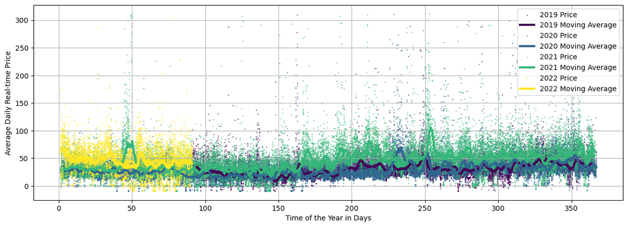

```python
lower_bound = pricing_data_df['rt_price'].quantile(0.005)
upper_bound = pricing_data_df['rt_price'].quantile(0.995)

no_outlier_pricing_df = pricing_data_df[(pricing_data_df['rt_price'] >= lower_bound) & (pricing_data_df['rt_price'] <= upper_bound)]

years = no_outlier_pricing_df['year'].unique()
colors = plt.cm.viridis(np.linspace(0, 1, len(years)))
plt.figure(figsize=(15, 5))
for year, color in zip(years, colors):
    subset = no_outlier_pricing_df[no_outlier_pricing_df['year'] == year]
    plt.scatter(subset['time_of_year'], subset['rt_price'], label=f'{year} Price', color=color, alpha=1, s=.2)
    moving_average = subset['rt_price'].rolling(window=300).mean()
    plt.plot(subset['time_of_year'], moving_average, label=f'{year} Moving Average', color=color, linewidth=3)
plt.xlabel("Time of the Year in Days")
plt.ylabel("Average Daily Real-time Price")
plt.legend()
plt.grid(True)
plt.show()
```

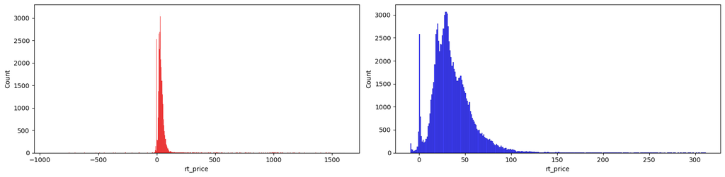

```python
plt.figure(figsize=fig_size)
plt.subplot(1, 2, 1)
sns.histplot(pricing_data_df['rt_price'], kde=False, color='red')
plt.subplot(1, 2, 2)
sns.histplot(no_outlier_pricing_df['rt_price'], kde=False, color='blue')
plt.tight_layout()
plt.show()
```

Removing 0.5% outlier has improved the distribution of the data. Without outlier, the shape of the histogram is very leptokurtic. With outlier removal, the shape is more normal distribution and thus easier for the models to learn.

## Maching Learning Models

- LSTM
- Transformer

### Preprocessing the Data

The following preprocessing steps are performed:

1. **Data Preparation**
2. **Feature Engineering**
3. **Outlier Detection and Removal**
4. **Splitting, Normalization and Sequencing**
5. **Loss Function and Optimizer**

```python
device = torch.device("cuda" if torch.cuda.is_available() else "cpu")
batch_size = 1024
timesteps_ahead = 24
seq_len = int(96)
random_seed = 287
learning_rate = 0.0003

if TRAIN:
    train_losses = []
    val_losses = []
```

#### Outlier Detection and Removal

The command to remove outliers is **disabled** to report the metrics on unseen test dataset, during evaluation.

```python
lower_bound = pricing_data_df['rt_price'].quantile(0.005)
upper_bound = pricing_data_df['rt_price'].quantile(0.995)

if TRAIN:
    pricing_data_df = pricing_data_df[(pricing_data_df['rt_price'] >= lower_bound) & (pricing_data_df['rt_price'] <= upper_bound)]
```

#### Feature Selection

```python
features = ['temp', 'time_of_year', 'dah_price', 'year', 'rt_price']
target = 'rt_price'
input_data = pricing_data_df[features].copy()
input_data['target_rt_price'] = input_data['rt_price'].shift(-timesteps_ahead)
feature_data = input_data.values[:, :-1]
target_data = np.expand_dims(input_data.values[:, -1], axis=1)
```

#### Data Preparation

Three datasets are created: training, validation, and test (latest 10% of data). The target variable 'target_rt_price' is created by shifting 'rt_prices' by 24 timesteps (6 hours). Input features are a sequence of length 96 (seq_len=96) with 5 features (n_features=5), representing a 24-hour window.

Preprocessing:

The validation set is used to monitor overfitting during training, while the test set evaluates final model performance on unseen data, mimicking real-world scenarios.

```python
sequence_data = np.lib.stride_tricks.sliding_window_view(input_data.values, window_shape=(seq_len, input_data.shape[1])).squeeze(1)

X = sequence_data[:-1, :, :-1].astype('float32') # number_of_seqs, seq_len, features
Y = sequence_data[:-1, -timesteps_ahead, -1].astype('float32') # number_of_seqs, seq_len, 1

X_train, X_test, y_train, y_test = sklearn.model_selection.train_test_split(X, Y, test_size=0.1, shuffle=False)
```

```python
times_of_year = X_test[:, (seq_len-1), 1] # in days and their fractional part

# Calculating future prediction hours by adding 6, and wrap around using modulo 24
hours_of_day = ((times_of_year % 1) * 24 + 6) % 24

on_peak_hours = (hours_of_day >= 8) & (hours_of_day < 24)
off_peak_hours = ~on_peak_hours

X_test_on_peak = X_test[on_peak_hours]
X_test_off_peak = X_test[off_peak_hours]
y_test_on_peak = y_test[on_peak_hours]
y_test_off_peak = y_test[off_peak_hours]

X_test_on_peak = torch.tensor(X_test_on_peak, device=device)
X_test_off_peak = torch.tensor(X_test_off_peak, device=device)
y_test_on_peak = torch.tensor(y_test_on_peak, device=device)
y_test_off_peak = torch.tensor(y_test_off_peak, device=device)
```

#### Normalization and Sequencing

- The dataset is split into training, validation, and test sets.
- Target column 'target_rt_price' is added by shifting the current rt_prices by 24 timesteps(6 hours). This column is used as the target while a sequence of **(seq_len=96, n_features=5)** is used for input
- Standard scaling is applied separately to the training and test sets using the `StandardScaler` from scikit-learn.
- Multi-variate time-series models require the data to in the form of sequences. We create sequences of 96 timesteps(one day) to be fed into the model.

```python
# Applying seperate scaling parameters of train set on the test set
scaler = StandardScaler()

X_train_reshaped = X_train.reshape(-1, X_train.shape[2])
X_test_reshaped = X_test.reshape(-1, X_test.shape[2])

scaler.fit(X_train_reshaped)
X_train_scaled = scaler.transform(X_train_reshaped)
X_test_scaled = scaler.transform(X_test_reshaped)

X_train = X_train_scaled.reshape(X_train.shape)
X_test = X_test_scaled.reshape(X_test.shape)
```

We further splot the training set into training and validation set.

```python
X_train, X_val, y_train, y_val = sklearn.model_selection.train_test_split(X_train, y_train, test_size=0.1, random_state=random_seed, shuffle=True)

X_train_tensor = torch.tensor(X_train, dtype=torch.float32, device=device)
X_val_tensor = torch.tensor(X_val, dtype=torch.float32, device=device)
X_test_tensor = torch.tensor(X_test, dtype=torch.float32, device=device)
y_train_tensor = torch.tensor(y_train, dtype=torch.float32, device=device)
y_val_tensor = torch.tensor(y_val, dtype=torch.float32, device=device)
y_test_tensor = torch.tensor(y_test, dtype=torch.float32, device=device)

train_dataset = TensorDataset(X_train_tensor, y_train_tensor)
val_dataset = TensorDataset(X_val_tensor, y_val_tensor)
test_dataset = TensorDataset(X_test_tensor, y_test_tensor)

train_loader = DataLoader(dataset=train_dataset, batch_size=batch_size, shuffle=True)
val_loader = DataLoader(dataset=val_dataset, batch_size=batch_size, shuffle=True)
test_loader = DataLoader(dataset=test_dataset, batch_size=batch_size, shuffle=True)
```

### LSTM Model

Now we will set up the LSTM model

#### Loss Function and Optimizer:

- L1 Loss(MAE) is chosen over MSE as the loss function since MSE penalizes large errors more heavily, causing the model to overfocus on rare events. With most data concentrated around the mean, MAE ensures the model accurately predicts typical outputs by minimizing absolute errors across the entire range.
- Adam optimizer is chosen because it uses momentum and adaptive learning rate, which helps accelerate convergence and maintains a steady training pace.

```python
n_features = X_train_tensor.shape[2]
hidden_dim = 200
seq_len = X_train_tensor.shape[1]
num_epochs = 50

lstm_model = LSTMModel(input_dim=n_features, hidden_dim=hidden_dim, output_dim=1, num_layers=1).to(device)
print(torchinfo.summary(lstm_model))
criterion = torch.nn.L1Loss()
optimizer = torch.optim.Adam(lstm_model.parameters(), lr = 0.001, weight_decay=0.01)
```

```
=================================================================
Layer (type:depth-idx)                   Param #
=================================================================
LSTMModel                                --
├─LSTM: 1-1                              165,600
├─Linear: 1-2                            10,050
├─Linear: 1-3                            51
=================================================================
Total params: 175,701
Trainable params: 175,701
Non-trainable params: 0
=================================================================
```

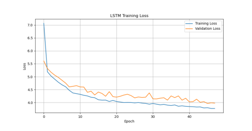

```python
if TRAIN:
    train_model(model=lstm_model, train_loader=train_loader, val_loader=val_loader, device=device, optimizer=optimizer, criterion=criterion, num_epochs=num_epochs, model_save_path="data/transformer.pth" )
else:
    img = mpimg.imread('figures/lstm_training_loss.png')
    plt.imshow(img)
    plt.axis('off')
    plt.show()
```

```python
# loading the best model
lstm_model = torch.load(f'saved_models/LSTM_{hidden_dim}.pth')
```

```python
results = evaluate_model_with_dataloader(lstm_model, criterion, test_loader, device)
print(f"LSTM Test set RMSE: {results['RMSE']:.4f}")
print(f"LSTM Test set MAPE: {results['MAPE']:.2f}%")
```

```
LSTM Test set RMSE: 4.1015
LSTM Test set MAPE: 1932026739.73%
```

Mean Absolute Percentage Error is very high because many values are close to zero. Extremely small values can increase the percentage error, as in our case. In our case, RMSE is a better metric to judge model performance.

We can change the starting index and range to visualize the predicted and actual values.

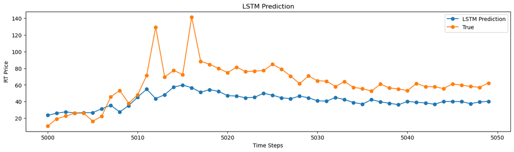

```python
start_index = 5000
sample_range = 50

X_test_sample = torch.tensor(X_test[start_index:start_index + sample_range], dtype=torch.float32, device=device)
y_test_sample = y_test[start_index-1:start_index + sample_range-1]

with torch.no_grad():
    lstm_preds = lstm_model(X_test_sample).cpu().numpy().flatten()

x_values = np.arange(start_index, start_index + sample_range)

plt.figure(figsize=fig_size)
plt.plot(x_values, lstm_preds, label='LSTM Prediction', marker='o')
plt.plot(x_values, y_test_sample, label='True', marker='o')
plt.title('LSTM Prediction')
plt.xlabel('Time Steps')
plt.ylabel('RT Price')
plt.legend()
plt.show()
```

## Transformer

The Transformer model, popularized by GPT-3, usually needs a lot of data to work well. Despite this, we're going to train a Transformer with a decoder setup and causal self-attention to see how it performs on our energy price data.

```python
from models import TimeSeriesTransformer

n_layer = 2
n_embd = 64
n_heads = 4
block_size = 96
max_block_size = 96*7
grad_accum_steps = 4
n_features = 5
learning_rate = 0.001
num_epochs = 50

trans_model = TimeSeriesTransformer(n_features, n_embd, n_heads,max_block_size, n_layer, device).to(device)

print(torchinfo.summary(trans_model))
criterion = torch.nn.L1Loss()
optimizer = torch.optim.Adam(trans_model.parameters(), lr = learning_rate, weight_decay=0.01)
```

```
======================================================================
Layer (type:depth-idx)                        Param #
======================================================================
TimeSeriesTransformer                         --
├─ModuleDict: 1-1                             --
│    └─Linear: 2-1                            384
│    └─Embedding: 2-2                         43,008
│    └─ModuleList: 2-3                        --
│    │    └─Block: 3-1                        49,152
│    │    └─Block: 3-2                        49,152
├─Linear: 1-2                                 64
======================================================================
Total params: 141,760
Trainable params: 141,760
Non-trainable params: 0
======================================================================
```

[figure not shown]

```python
if TRAIN:
    # print("skipping training")
    train_model(model=trans_model, train_loader=train_loader, val_loader=val_loader, device=device, optimizer=optimizer, criterion=criterion, num_epochs=num_epochs*2, model_save_path=f'saved_models/transformer_{n_embd}_{n_heads}.pth' )
else:
    img = mpimg.imread('figures/lstm_training_loss.png')
    plt.imshow(img)
    plt.axis('off')
    plt.show()
```

```python
# Loading the best saved model
trans_model = torch.load(f'saved_models/transformer_{n_embd}_{n_heads}.pth')
```

```python
results = evaluate_model_with_dataloader(trans_model, criterion, test_loader, device)
print(f"Test set RMSE: {results['RMSE']:.4f}")
print(f"Test set MAPE: {results['MAPE']:.2f}%")
```

```
Test set RMSE: 3.9331
Test set MAPE: 2034685364.99%
```

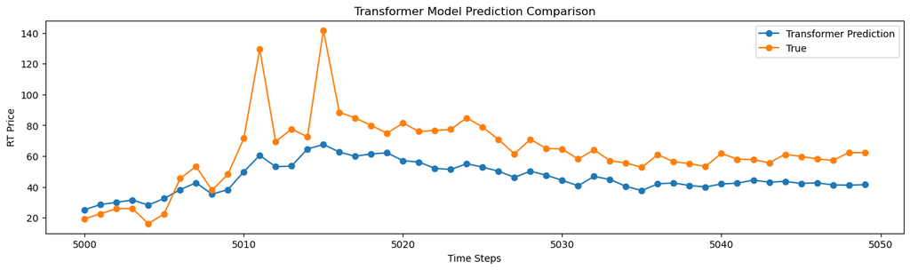

```python
start_index = 5000
sample_range = 50

X_test_sample = torch.tensor(X_test[start_index:start_index + sample_range], dtype=torch.float32, device=device)
y_test_sample = y_test[start_index:start_index + sample_range]

with torch.no_grad():
    trans_preds = trans_model(X_test_sample).cpu().numpy().flatten()

x_values = np.arange(start_index, start_index + sample_range)

plt.figure(figsize=fig_size)
plt.plot(x_values, trans_preds, label='Transformer Prediction', marker='o')
plt.plot(x_values, y_test_sample, label='True', marker='o')
plt.title('Transformer Model Prediction Comparison')
plt.xlabel('Time Steps')
plt.ylabel('RT Price')
plt.legend()
plt.show()
```

## Models' Performance Comparison

Now we are comparing the two trained models.

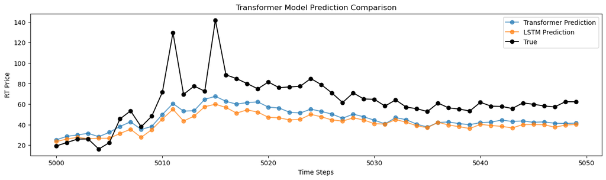

```python
plt.figure(figsize=fig_size)
plt.plot(x_values, trans_preds, label='Transformer Prediction', marker='o', alpha=.7)
plt.plot(x_values, lstm_preds, label='LSTM Prediction', marker='o', alpha=.7)
plt.plot(x_values, y_test_sample, label='True', marker='o', color='k')
plt.title('Transformer Model Prediction Comparison')
plt.xlabel('Time Steps')
plt.ylabel('RT Price')
plt.legend()
plt.show()
```

```python
trans_results = evaluate_model(trans_model, criterion, X_test_tensor, y_test_tensor)
print(f"Transformer Test RMSE : {trans_results['RMSE']:.4f}")

lstm_results = evaluate_model(lstm_model, criterion, X_test_tensor, y_test_tensor)
print(f"LSTM Test RMSE : {lstm_results['RMSE']:.4f}")
```

```
Transformer Test RMSE : 3.9331
LSTM Test RMSE : 4.1015
```

Now we calculate on peak and off peak RMSE for LSTM

```python
lstm_on_peak = evaluate_model(lstm_model, criterion, X_test_on_peak, y_test_on_peak)
print(f"LSTM Test On Peak RMSE : {lstm_on_peak['RMSE']:.4f}")

lstm_off_peak = evaluate_model(lstm_model, criterion, X_test_off_peak, y_test_off_peak)
print(f"LSTM Test Off Peak RMSE : {lstm_off_peak['RMSE']:.4f}")
```

```
LSTM Test On Peak RMSE : 4.5324
LSTM Test Off Peak RMSE : 4.3205
```

## Conclusion

The results of both LSTM and Transformer are comparable. Both models have around same number of parameters but transformer takes double the epochs to achieve same results.

## Further Ideas

Here we list the things that can be performed if we have more time:

- **Multiple Models**: Multiple ensemble models can be trained and then their average can be taken as final results. Similaly, seperate models for on-peak and off-peak can be trained.
- **Feature Engineering**: Different features can be tested like adding week_of_day and others. Similarly, more features can be generated like moving averages over different time periods to help the model make better prediction.
- **Outlier Identification**: Outliers can be removed in a better way i.e. removing all data points for specific outlier events.
- **Incorporating ARIMA**: Incorporating ARIMA (AutoRegressive Integrated Moving Average) components or other traditional time series forecasting methods with deep learning models can yield a hybrid model that captures linear and non-linear relationships more effectively.
- **Different Model Architectures and Sizes**: We only used only size of model for training. We can experiment with different sizes and architetures(maybe RNN with 4 times the cells of LSTM?). We could also try adding regularization like L2 regularization and dropout techniques.
- **Hyperparameters Experimentation**: Different learning rates could also be tested.

## Real-World Deployment Considerations

- We observe long-term trends in data i.e. higher prices over the years. Due to this, we need to implement techniques to monitor data distribution drifts.
- We observe that model's predictions get worse as we try to predict farther in time(close to the ending of the data). Constant model training is necessary for the model to learn the recent events.
- As discussed earlier, the rare events are causing outliers in the data. More features are needed which can explain the cause of the data for better predictions in those rare events. They could be simple as two binary variables for over-supply/over-demand events, or they could also be detailed cause of the events like intensity of sun(which would impact the electricity supply and thus prices)